# Modeling and Optimization

Dynamic Programming

Sebastian Souyris

MGMT 6460 Fall 2026

## Roadmap

1. **Part I. Stages, States and the Recursion**
   - Sequential Decisions: The Stagecoach Problem
   - Stages, States and the Bellman Recursion
   - Backward Induction on a Staged Network
   - Distribution of Effort: Allocating Medical Teams
   - Knapsacks: Dynamic Versus Integer Programming
   - Practice: Backward Recursion on a Network

## Roadmap, Continued

2. **Part II. Continuous States and Chance**
   - Discrete and Continuous States: The Endpoint Argument
   - Continuous States by Calculus: Employment Levels
   - Probabilistic Recursions: Maximizing a Probability
   - Expected-Cost Recursions: A State-Dependent Policy
   - Practice: Allocation and Betting Recursions
3. **Part III. Infinite Horizons and Learning**
   - Markov Decision Processes and the Bellman Equation
   - Value Iteration and Linear Programming
   - Reinforcement Learning: Q-Learning from Samples
   - Practice: Integer and Continuous Recursions
4. Conclusions
5. Appendix: References and the Job Shop Algebra

# Sequential Decisions: The Stagecoach Problem

## Four Legs from A to J

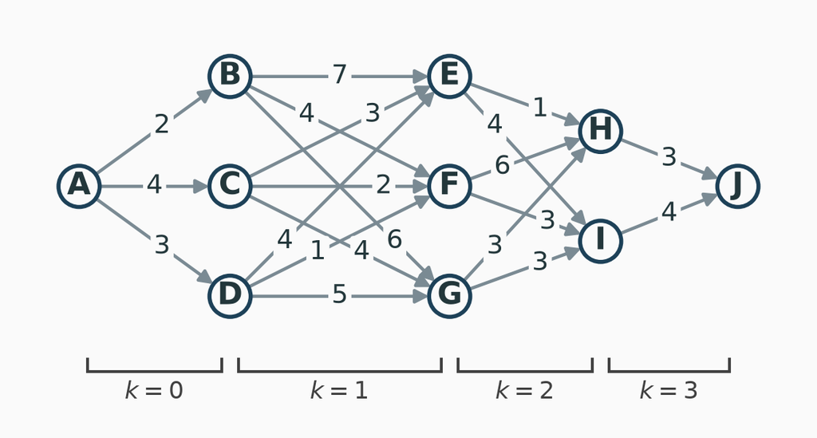

- A traveler crosses from town A to town J in **four legs** by stagecoach
- Each leg needs a life insurance policy; the number on an arc is its cost
- Which route costs the least in total?
- Revisiting the shortest path problem

## The Cheapest Next (Greedy heuristic) Leg Misses the Optimum

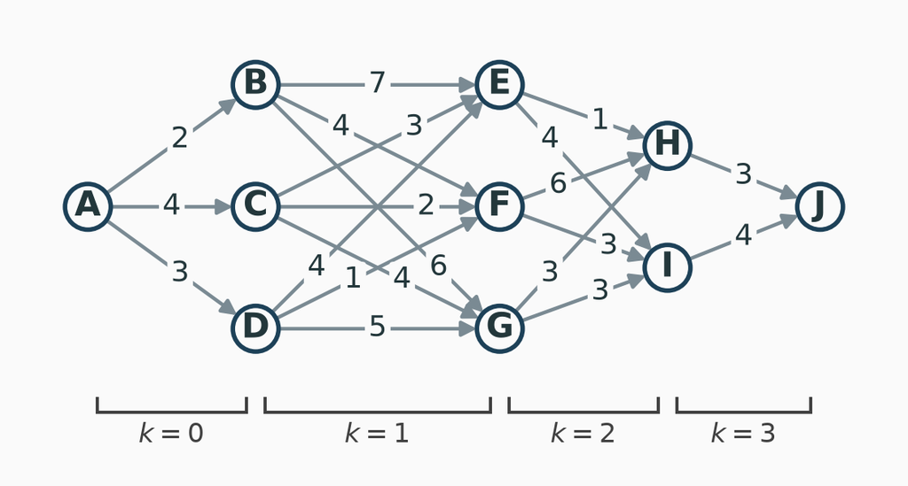

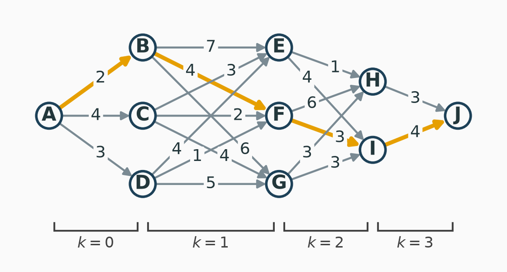

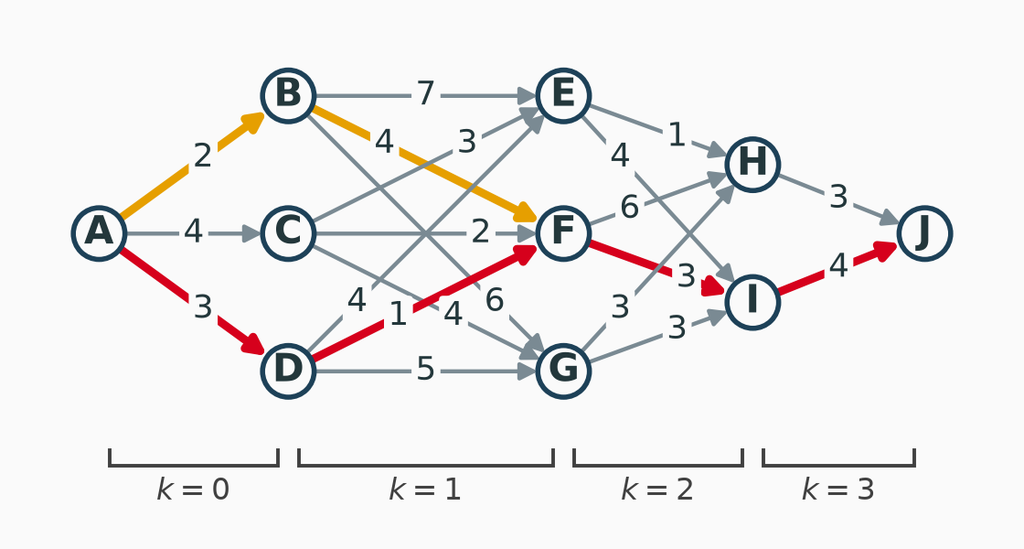

**Cheapest next leg:** A–B–F–I–J, ${2 + 4 + 3 + 4 = 13}$

**Better:** A–D–F–I–J, ${3 + 1 + 3 + 4 = 11}$

Paying 1 more on leg 1 saves 3 on leg 2.

## Enumerate, or Use the Stages

- All routes: ${3 \times 3 \times 2 = 18}$. Three cost 11; the next best cost 13
- With 10 stages of 10 towns each: ${10^9}$ routes to add up

**The idea of dynamic programming**

- Solve the problem from the **last stage**: one leg from J.
- Then enlarge it one stage at a time, reusing the answer for the stages already solved.
- Each arc is used in **one addition**: 20 here, about 1,000 for 10 stages of 10 towns.

# Stages, States and the Bellman Recursion

## Stages, States and Controls

| Term | Symbol | Stagecoach |
| --- | --- | --- |
| Stage | ${k = 0, \dots, N - 1}$ | Leg ${k + 1}$; ${N = 4}$ |
| State | ${x_k}$ | Town at the start of the leg |
| Control | ${u_k \in U_k(x_k)}$ | Next town |
| System | ${x_{k+1} = f_k(x_k, u_k)}$ | ${x_{k+1} = u_k}$ |

The **state** summarizes the past information relevant for the future. The **system** ${f_k}$ is the **state transition function**.

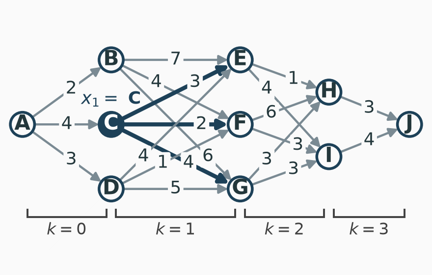

At stage 1 in state C: ${U_1(\text{C}) = \{\text{E}, \text{F}, \text{G}\}}$.

## Costs, Cost-to-Go and Policies

| Term | Symbol | Stagecoach |
| --- | --- | --- |
| Stage cost | ${g_k(x_k, u_k)}$ | Premium of the leg |
| Terminal cost | ${g_N(x_N)}$ | ${g_4(\text{J}) = 0}$ |
| Total cost, **additive** in the basic problem | ${g_N(x_N) + \sum_{k=0}^{N-1} g_k(x_k, u_k)}$ | Sum of the four premiums |
| Optimal cost-to-go | ${J^*_k(x_k)}$ | Least cost from ${x_k}$ to J |
| Policy | ${\pi = \{\mu_0, \dots, \mu_{N-1}\}}$, ${u_k = \mu_k(x_k)}$ | Next town from every town |

**Cost-to-go**

${J^*_k(x_k)}$: the least cost of the stages left, from ${x_k}$; the value function of the tail

## The DP Algorithm

Start at the end, then go backward one stage at a time:

$$\begin{alignat*}{2}
J^*_N(x_N) & {}= g_N(x_N) \\[4pt]
J^*_k(x_k) & {}= \min_{u_k \in U_k(x_k)} \Big[\, g_k(x_k, u_k) + J^*_{k+1}\big(f_k(x_k, u_k)\big) \Big] && \qquad k = N - 1, \dots, 0
\end{alignat*}$$

- The bracket is the Q-factor ${Q^*_k(x_k, u_k)}$: control ${u_k}$ now, then the best from the state it leads to. The next section computes it for every ${x_k}$ and ${u_k}$, one table per stage
- Stagecoach: ${J^*_k(x_k) = \min_{u_k} \big[ c_{x_k u_k} + J^*_{k+1}(u_k) \big]}$, ${J^*_4(\text{J}) = 0}$
- ${J^*_0(\text{A})}$ is the least total cost; the minimizers ${\mu^*_k(x_k)}$ form an optimal policy

## The Principle of Optimality

**Bellman (1957)**

An optimal policy has the property that whatever the initial state and initial decision are, the remaining decisions must constitute an optimal policy with regard to the state resulting from the first decision.

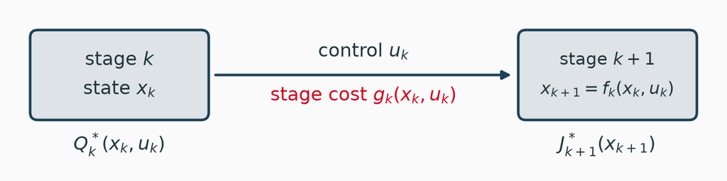

- The tail of an optimal policy is optimal for the tail subproblem that starts at ${x_k}$: the future ignores how the process got there

## What Makes a Problem a Dynamic Program

1. **Stages** ${k = 0, \dots, N - 1}$
2. A **state** ${x_k}$ that holds what the future needs to know of the past
3. A **control** ${u_k \in U_k(x_k)}$: the action or decision at stage ${k}$
4. A **system** (or state transition function) ${x_{k+1} = f_k(x_k, u_k)}$
5. A cost that **separates** by stage: a sum, a product or a max; another function of the total goes in ${g_N}$, with the running total in the state
6. The **DP algorithm** gives ${J^*_k}$ from ${J^*_{k+1}}$, last stage first

**Deterministic dynamic programming**

- Part II adds a random **disturbance** ${w_k}$: ${x_{k+1} = f_k(x_k, u_k, w_k)}$

# Backward Induction on a Staged Network

## Stage 3: One Leg to J

| *k* = 3 *x*<sub>3</sub> | *J*<sub>3</sub>*(*x*<sub>3</sub>) | *u*<sub>3</sub>* |
| --- | --- | --- |
| H | 3 | J |
| I | 4 | J |

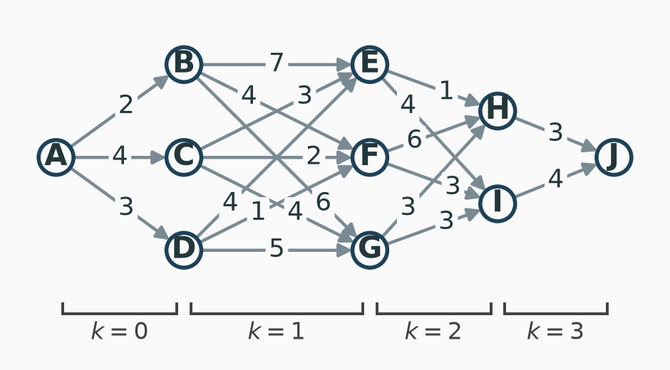

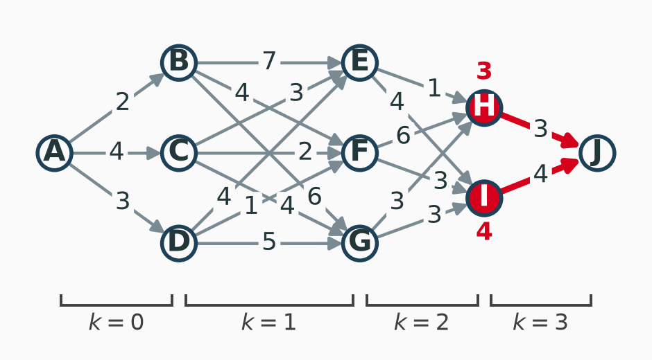

## Stage 2: Two Legs to J

| *k* = 3 *x*<sub>3</sub> | *J*<sub>3</sub>*(*x*<sub>3</sub>) | *u*<sub>3</sub>* |
| --- | --- | --- |
| H | 3 | J |
| I | 4 | J |

| *k* = 2 *x*<sub>2</sub> | *Q*<sub>2</sub>*(*x*<sub>2</sub>, *u*<sub>2</sub>) = *g*<sub>2</sub> + *J*<sub>3</sub>*(*u*<sub>2</sub>) H | *Q*<sub>2</sub>*(*x*<sub>2</sub>, *u*<sub>2</sub>) = *g*<sub>2</sub> + *J*<sub>3</sub>*(*u*<sub>2</sub>) I | *J*<sub>2</sub>*(*x*<sub>2</sub>) | *u*<sub>2</sub>* |  |  |
| --- | --- | --- | --- | --- | --- | --- |
| E | 1 + 3 = 4 | 4 + 4 = 8 |  |  | 4 | H |
| F | 6 + 3 = 9 | 3 + 4 = 7 | 7 | I |  |  |
| G | 3 + 3 = 6 | 3 + 4 = 7 | 6 | H |  |  |

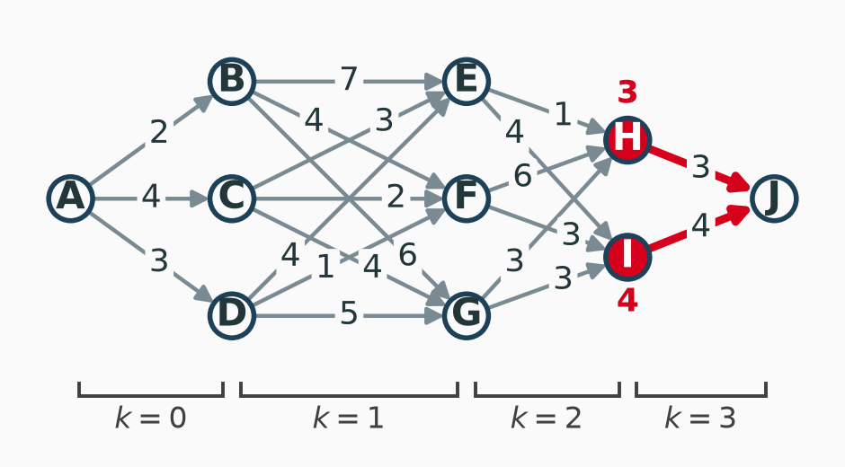

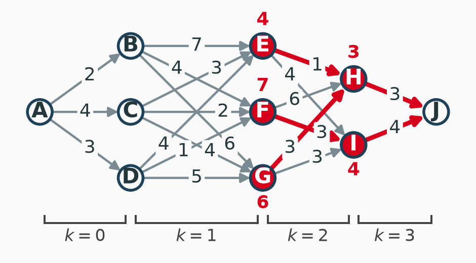

## Stage 1: Three Legs to J

| *k* = 2 *x*<sub>2</sub> | *Q*<sub>2</sub>*(*x*<sub>2</sub>, *u*<sub>2</sub>) = *g*<sub>2</sub> + *J*<sub>3</sub>*(*u*<sub>2</sub>) H | *Q*<sub>2</sub>*(*x*<sub>2</sub>, *u*<sub>2</sub>) = *g*<sub>2</sub> + *J*<sub>3</sub>*(*u*<sub>2</sub>) I | *J*<sub>2</sub>*(*x*<sub>2</sub>) | *u*<sub>2</sub>* |  |  |
| --- | --- | --- | --- | --- | --- | --- |
| E | 1 + 3 = 4 | 4 + 4 = 8 |  |  | 4 | H |
| F | 6 + 3 = 9 | 3 + 4 = 7 | 7 | I |  |  |
| G | 3 + 3 = 6 | 3 + 4 = 7 | 6 | H |  |  |

| *k* = 1 *x*<sub>1</sub> | *Q*<sub>1</sub>*(*x*<sub>1</sub>, *u*<sub>1</sub>) = *g*<sub>1</sub> + *J*<sub>2</sub>*(*u*<sub>1</sub>) E | *Q*<sub>1</sub>*(*x*<sub>1</sub>, *u*<sub>1</sub>) = *g*<sub>1</sub> + *J*<sub>2</sub>*(*u*<sub>1</sub>) F | *Q*<sub>1</sub>*(*x*<sub>1</sub>, *u*<sub>1</sub>) = *g*<sub>1</sub> + *J*<sub>2</sub>*(*u*<sub>1</sub>) G | *J*<sub>1</sub>*(*x*<sub>1</sub>) | *u*<sub>1</sub>* |  |  |
| --- | --- | --- | --- | --- | --- | --- | --- |
| B | 7 + 4 = 11 | 4 + 7 = 11 | 6 + 6 = 12 |  |  | 11 | E or F |
| C | 3 + 4 = 7 | 2 + 7 = 9 | 4 + 6 = 10 | 7 | E |  |  |
| D | 4 + 4 = 8 | 1 + 7 = 8 | 5 + 6 = 11 | 8 | E or F |  |  |

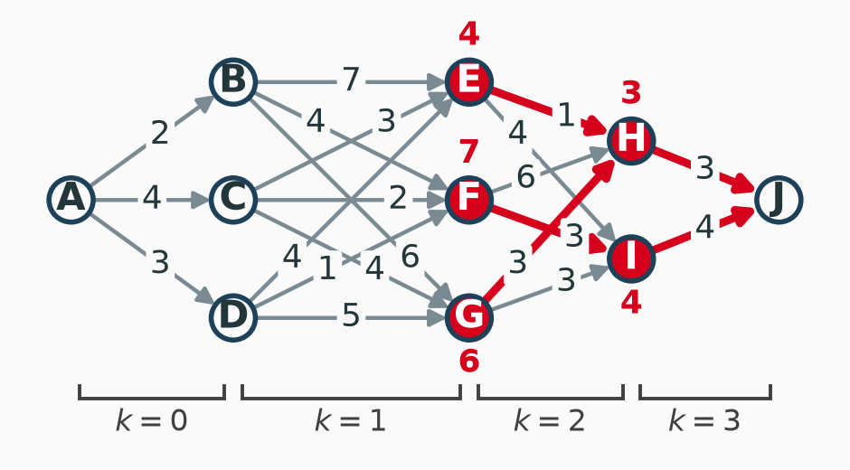

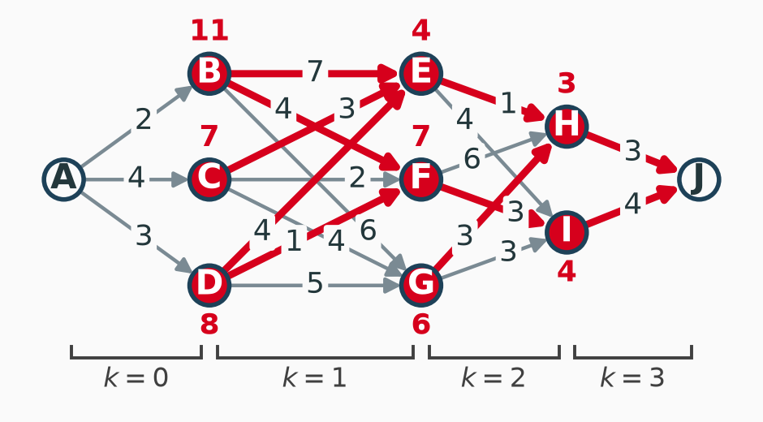

## Stage 0: Four Legs to J

| *k* = 1 *x*<sub>1</sub> | *Q*<sub>1</sub>*(*x*<sub>1</sub>, *u*<sub>1</sub>) = *g*<sub>1</sub> + *J*<sub>2</sub>*(*u*<sub>1</sub>) E | *Q*<sub>1</sub>*(*x*<sub>1</sub>, *u*<sub>1</sub>) = *g*<sub>1</sub> + *J*<sub>2</sub>*(*u*<sub>1</sub>) F | *Q*<sub>1</sub>*(*x*<sub>1</sub>, *u*<sub>1</sub>) = *g*<sub>1</sub> + *J*<sub>2</sub>*(*u*<sub>1</sub>) G | *J*<sub>1</sub>*(*x*<sub>1</sub>) | *u*<sub>1</sub>* |  |  |
| --- | --- | --- | --- | --- | --- | --- | --- |
| B | 7 + 4 = 11 | 4 + 7 = 11 | 6 + 6 = 12 |  |  | 11 | E or F |
| C | 3 + 4 = 7 | 2 + 7 = 9 | 4 + 6 = 10 | 7 | E |  |  |
| D | 4 + 4 = 8 | 1 + 7 = 8 | 5 + 6 = 11 | 8 | E or F |  |  |

| *k* = 0 *x*<sub>0</sub> | *Q*<sub>0</sub>*(*x*<sub>0</sub>, *u*<sub>0</sub>) = *g*<sub>0</sub> + *J*<sub>1</sub>*(*u*<sub>0</sub>) B | *Q*<sub>0</sub>*(*x*<sub>0</sub>, *u*<sub>0</sub>) = *g*<sub>0</sub> + *J*<sub>1</sub>*(*u*<sub>0</sub>) C | *Q*<sub>0</sub>*(*x*<sub>0</sub>, *u*<sub>0</sub>) = *g*<sub>0</sub> + *J*<sub>1</sub>*(*u*<sub>0</sub>) D | *J*<sub>0</sub>*(*x*<sub>0</sub>) | *u*<sub>0</sub>* |  |  |
| --- | --- | --- | --- | --- | --- | --- | --- |
| A | 2 + 11 = 13 | 4 + 7 = 11 | 3 + 8 = 11 |  |  | 11 | C or D |

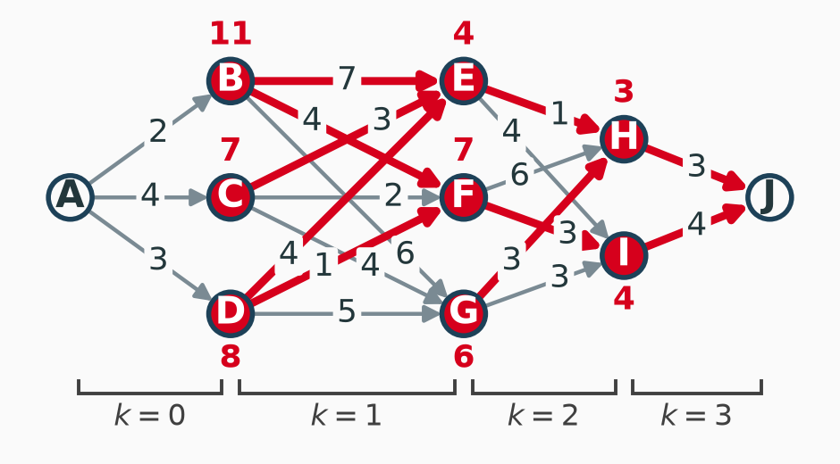

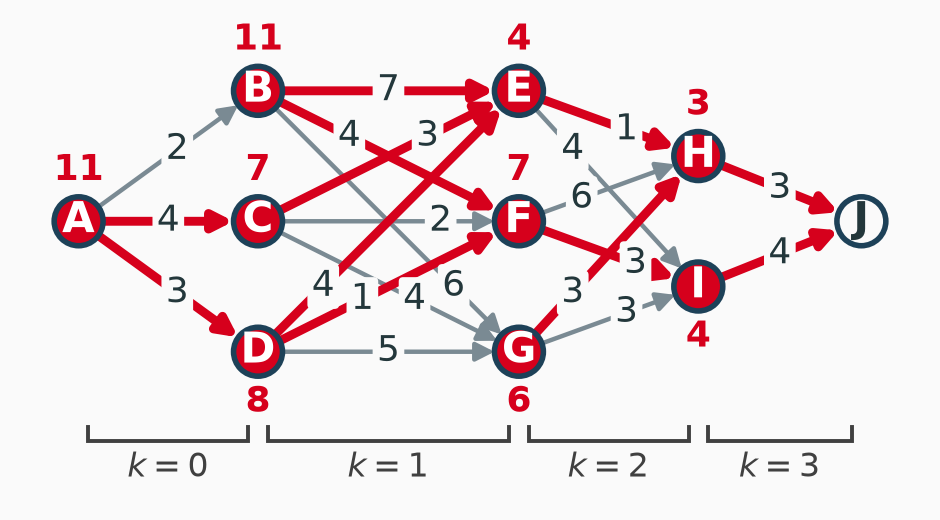

## Reading the Routes Forward

- Stage 0: ${u^*_0}$ = C or D
- From C: E, then H, then J
- From D: E (then H, J) or F (then I, J)

**Three optimal routes, cost 11**

A–C–E–H–J  
A–D–E–H–J  
A–D–F–I–J

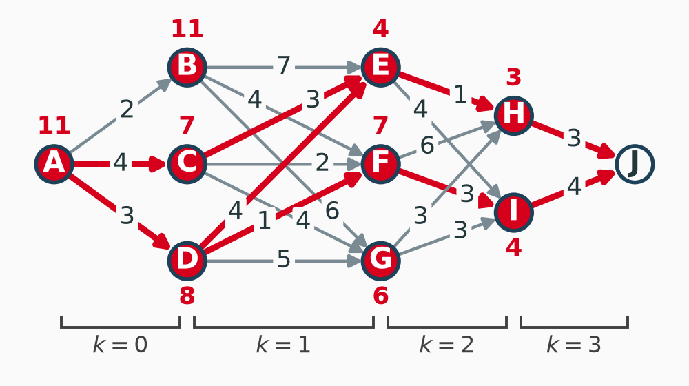

## Dynamic Programming and the Shortest Path Algorithm

The stagecoach is a shortest path problem; lecture 06’s algorithm also finds 11.

|  | Shortest path algorithm | Dynamic programming |
| --- | --- | --- |
| Order | Nodes, nearest first | Stages, last first |
| Work per step | Scan the solved nodes’ neighbors | One addition per arc |
| Networks | Any, lengths ${\ge 0}$ | Staged, lengths of any sign |
| Result | Best paths from the origin | A control ${\mu_k(x_k)}$ for every state |

**When the network comes in stages**

Dynamic programming uses the stages: no search for the next nearest node, and the answer is a **policy** for every state.

# Distribution of Effort: Allocating Medical Teams

## Five Medical Teams, Three Countries

Additional person-years of life, in thousands

| Teams | Country 1 | Country 2 | Country 3 |
| --- | --- | --- | --- |
| 0 | 0 | 0 | 0 |
| 1 | 45 | 20 | 50 |
| 2 | 70 | 45 | 70 |
| 3 | 90 | 75 | 80 |
| 4 | 105 | 110 | 100 |
| 5 | 120 | 150 | 130 |

- A health council has **five medical teams** for three low-income countries
- Teams stay intact: each country gets a whole number of them
- **Decide** how many teams each country gets, to maximize the total person-years of life added

## Countries as Stages, Teams Left as the State

- Stage ${k}$: country ${k + 1}$; control ${u_k}$: its teams
- State ${x_k}$: teams still free; ${x_0 = 5}$, ${x_{k+1} = x_k - u_k}$
- Stage reward ${g_k(u_k)}$: country ${k + 1}$’s column

$$\begin{alignat*}{2}
J^*_k(x_k) & {}= \max_{u_k = 0, \dots, x_k} \big[\, g_k(u_k) + J^*_{k+1}(x_k - u_k) \big]
\end{alignat*}$$

With ${J^*_3 = 0}$, country 3 takes every team left: ${J^*_2(x_2) = g_2(x_2)}$.

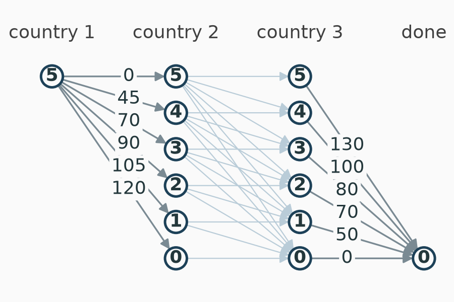

An arc from ${x_1}$ to ${x_2}$ earns ${g_1(x_1 - x_2)}$: the best path is the best allocation.

## In Class: Fill the Backward Tables

**Download Medical_Teams_DP.xlsx and open it**

The data and three empty tables, laid out as below:

1. Stage 2: ${J^*_2(x_2)}$ for ${x_2 = 0, \dots, 5}$
2. Stage 1: ${Q^*_1(x_1, u_1)}$ for every ${u_1 \le x_1}$, then ${J^*_1}$ and ${u^*_1}$
3. Stage 0: ${x_0 = 5}$ only. Then read the allocation forward

| *k* = 1 *x*<sub>1</sub> | *Q*<sub>1</sub>*(*x*<sub>1</sub>, *u*<sub>1</sub>) = *g*<sub>1</sub>(*u*<sub>1</sub>) + *J*<sub>2</sub>*(*x*<sub>1</sub> − *u*<sub>1</sub>) 0 | *Q*<sub>1</sub>*(*x*<sub>1</sub>, *u*<sub>1</sub>) = *g*<sub>1</sub>(*u*<sub>1</sub>) + *J*<sub>2</sub>*(*x*<sub>1</sub> − *u*<sub>1</sub>) 1 | *Q*<sub>1</sub>*(*x*<sub>1</sub>, *u*<sub>1</sub>) = *g*<sub>1</sub>(*u*<sub>1</sub>) + *J*<sub>2</sub>*(*x*<sub>1</sub> − *u*<sub>1</sub>) 2 | *Q*<sub>1</sub>*(*x*<sub>1</sub>, *u*<sub>1</sub>) = *g*<sub>1</sub>(*u*<sub>1</sub>) + *J*<sub>2</sub>*(*x*<sub>1</sub> − *u*<sub>1</sub>) 3 | *Q*<sub>1</sub>*(*x*<sub>1</sub>, *u*<sub>1</sub>) = *g*<sub>1</sub>(*u*<sub>1</sub>) + *J*<sub>2</sub>*(*x*<sub>1</sub> − *u*<sub>1</sub>) 4 | *Q*<sub>1</sub>*(*x*<sub>1</sub>, *u*<sub>1</sub>) = *g*<sub>1</sub>(*u*<sub>1</sub>) + *J*<sub>2</sub>*(*x*<sub>1</sub> − *u*<sub>1</sub>) 5 | *J*<sub>1</sub>*(*x*<sub>1</sub>) | *u*<sub>1</sub>* |  |  |
| --- | --- | --- | --- | --- | --- | --- | --- | --- | --- | --- |
| 0 | · |  |  |  |  |  |  |  |  |  |
| 1 | · | · |  |  |  |  |  |  |  |  |
| 2 | · | · | · |  |  |  |  |  |  |  |
| 3 | · | · | · | · |  |  |  |  |  |  |
| 4 | · | · | · | · | · |  |  |  |  |  |
| 5 | · | · | · | · | · | · |  |  |  |  |

## Distribution of Effort Problems

**Distribution of effort**

One resource shared among activities, each with its own return table ${g_k(u_k)}$.

- The returns need only **combine stage by stage**: a sum here, a product in the research-teams example. Each ${g_k}$ can be any table: country 2’s rises slowly, then fast, so no ranking of the countries works
- Whole teams cost nothing extra: the states and controls are the integers 0 to 5
- Other examples: sales reps to regions, scientists to research teams, an ad budget to media

# Knapsacks: Dynamic Versus Integer Programming

## Loading a Truck

| Load | A | B | C | D |
| --- | --- | --- | --- | --- |
| Pallets | 2 | 3 | 4 | 5 |
| Pays ($100s) | 7 | 11 | 10 | 12 |
| Per pallet | 3.5 | 3.67 | 2.5 | 2.4 |

- The truck holds **7 pallets**; each load goes whole or not at all
- **Best pay per pallet first:** B, then A: ${11 + 7 = 18}$, 2 pallets empty

As an integer program (IP), ${x_i = 1}$ if load ${i}$ goes:

$$\begin{alignat*}{3}
\max~ & \rlap{7x_A + 11x_B + 10x_C + 12x_D} \\[4pt]
\text{s.t.}~ & 2x_A + 3x_B + 4x_C + 5x_D & \quad & {}\le 7 \\
& x_A, x_B, x_C, x_D & \quad & {}\in \{0, 1\}
\end{alignat*}$$

A **knapsack problem**: one constraint, yes-or-no items.

## The Knapsack as a Dynamic Program

- Stage ${k}$: load A, B, C, D for ${k = 0, \dots, 3}$; control ${u_k \in \{0, 1\}}$
- State ${x_k}$: pallets still free; ${x_0 = 7}$, ${x_{k+1} = x_k - a_k u_k}$
- ${u_k \in \{0, 1\}}$. ${u_k}$ can be equal to ${1}$ only if ${a_k \le x_k}$

$$\begin{alignat*}{2}
J^*_k(x_k) & {}= \max_{u_k \in \{0,1\}} \big[\, v_k\, u_k + J^*_{k+1}(x_k - a_k\, u_k) \big] \\[4pt]
J^*_4(x_4) & {}= 0
\end{alignat*}$$

- ${a_k}$: pallets; ${v_k}$: pay. States run from 0 to 7 at every stage but the first

## The Knapsack as a Longest Path

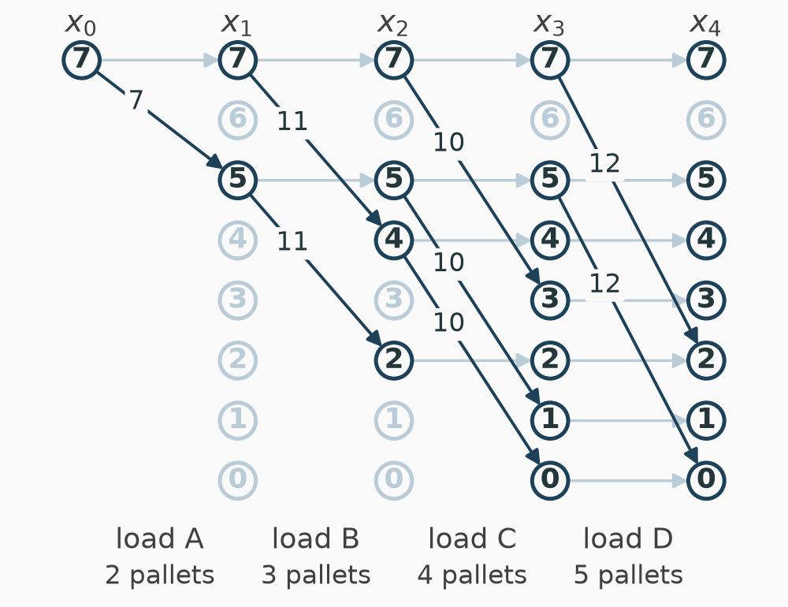

- Node: state ${x_k}$, the pallets still free
- Arc: control ${u_k}$
  - Grey, ${u_k = 0}$: skip the load, pay 0
  - Dark, ${u_k = 1}$: take it, earn ${v_k}$, use ${a_k}$ pallets
- A path is a loading, and its length is the pay: the best loading is the **longest path**

## Backward Tables: Loads D and C

| *k* = 3 *x*<sub>3</sub> | load D: 12*u*<sub>3</sub> + *J*<sub>4</sub>*(*x*<sub>3</sub> − 5*u*<sub>3</sub>) *u*<sub>3</sub> = 0 | load D: 12*u*<sub>3</sub> + *J*<sub>4</sub>*(*x*<sub>3</sub> − 5*u*<sub>3</sub>) *u*<sub>3</sub> = 1 | *J*<sub>3</sub>*(*x*<sub>3</sub>) | *u*<sub>3</sub>* |  |  |
| --- | --- | --- | --- | --- | --- | --- |
| 0 | 0 |  |  |  | 0 | 0 |
| 1 | 0 |  | 0 | 0 |  |  |
| 2 | 0 |  | 0 | 0 |  |  |
| 3 | 0 |  | 0 | 0 |  |  |
| 4 | 0 |  | 0 | 0 |  |  |
| 5 | 0 | 12 + 0 = 12 | 12 | 1 |  |  |
| 6 | 0 | 12 + 0 = 12 | 12 | 1 |  |  |
| 7 | 0 | 12 + 0 = 12 | 12 | 1 |  |  |

| *k* = 2 *x*<sub>2</sub> | load C: 10*u*<sub>2</sub> + *J*<sub>3</sub>*(*x*<sub>2</sub> − 4*u*<sub>2</sub>) *u*<sub>2</sub> = 0 | load C: 10*u*<sub>2</sub> + *J*<sub>3</sub>*(*x*<sub>2</sub> − 4*u*<sub>2</sub>) *u*<sub>2</sub> = 1 | *J*<sub>2</sub>*(*x*<sub>2</sub>) | *u*<sub>2</sub>* |  |  |
| --- | --- | --- | --- | --- | --- | --- |
| 0 | 0 |  |  |  | 0 | 0 |
| 1 | 0 |  | 0 | 0 |  |  |
| 2 | 0 |  | 0 | 0 |  |  |
| 3 | 0 |  | 0 | 0 |  |  |
| 4 | 0 | 10 + 0 = 10 | 10 | 1 |  |  |
| 5 | 12 | 10 + 0 = 10 | 12 | 0 |  |  |
| 6 | 12 | 10 + 0 = 10 | 12 | 0 |  |  |
| 7 | 12 | 10 + 0 = 10 | 12 | 0 |  |  |

## Backward Tables: Load B

| *k* = 2 *x*<sub>2</sub> | load C: 10*u*<sub>2</sub> + *J*<sub>3</sub>*(*x*<sub>2</sub> − 4*u*<sub>2</sub>) *u*<sub>2</sub> = 0 | load C: 10*u*<sub>2</sub> + *J*<sub>3</sub>*(*x*<sub>2</sub> − 4*u*<sub>2</sub>) *u*<sub>2</sub> = 1 | *J*<sub>2</sub>*(*x*<sub>2</sub>) | *u*<sub>2</sub>* |  |  |
| --- | --- | --- | --- | --- | --- | --- |
| 0 | 0 |  |  |  | 0 | 0 |
| 1 | 0 |  | 0 | 0 |  |  |
| 2 | 0 |  | 0 | 0 |  |  |
| 3 | 0 |  | 0 | 0 |  |  |
| 4 | 0 | 10 + 0 = 10 | 10 | 1 |  |  |
| 5 | 12 | 10 + 0 = 10 | 12 | 0 |  |  |
| 6 | 12 | 10 + 0 = 10 | 12 | 0 |  |  |
| 7 | 12 | 10 + 0 = 10 | 12 | 0 |  |  |

| *k* = 1 *x*<sub>1</sub> | load B: 11*u*<sub>1</sub> + *J*<sub>2</sub>*(*x*<sub>1</sub> − 3*u*<sub>1</sub>) *u*<sub>1</sub> = 0 | load B: 11*u*<sub>1</sub> + *J*<sub>2</sub>*(*x*<sub>1</sub> − 3*u*<sub>1</sub>) *u*<sub>1</sub> = 1 | *J*<sub>1</sub>*(*x*<sub>1</sub>) | *u*<sub>1</sub>* |  |  |
| --- | --- | --- | --- | --- | --- | --- |
| 0 | 0 |  |  |  | 0 | 0 |
| 1 | 0 |  | 0 | 0 |  |  |
| 2 | 0 |  | 0 | 0 |  |  |
| 3 | 0 | 11 + 0 = 11 | 11 | 1 |  |  |
| 4 | 10 | 11 + 0 = 11 | 11 | 1 |  |  |
| 5 | 12 | 11 + 0 = 11 | 12 | 0 |  |  |
| 6 | 12 | 11 + 0 = 11 | 12 | 0 |  |  |
| 7 | 12 | 11 + 10 = 21 | 21 | 1 |  |  |

## Backward Tables: Load A and the Forward Pass

| *k* = 1 *x*<sub>1</sub> | load B: 11*u*<sub>1</sub> + *J*<sub>2</sub>*(*x*<sub>1</sub> − 3*u*<sub>1</sub>) *u*<sub>1</sub> = 0 | load B: 11*u*<sub>1</sub> + *J*<sub>2</sub>*(*x*<sub>1</sub> − 3*u*<sub>1</sub>) *u*<sub>1</sub> = 1 | *J*<sub>1</sub>*(*x*<sub>1</sub>) | *u*<sub>1</sub>* |  |  |
| --- | --- | --- | --- | --- | --- | --- |
| 0 | 0 |  |  |  | 0 | 0 |
| 1 | 0 |  | 0 | 0 |  |  |
| 2 | 0 |  | 0 | 0 |  |  |
| 3 | 0 | 11 + 0 = 11 | 11 | 1 |  |  |
| 4 | 10 | 11 + 0 = 11 | 11 | 1 |  |  |
| 5 | 12 | 11 + 0 = 11 | 12 | 0 |  |  |
| 6 | 12 | 11 + 0 = 11 | 12 | 0 |  |  |
| 7 | 12 | 11 + 10 = 21 | 21 | 1 |  |  |

| *k* = 0 *x*<sub>0</sub> | load A: 7*u*<sub>0</sub> + *J*<sub>1</sub>*(*x*<sub>0</sub> − 2*u*<sub>0</sub>) *u*<sub>0</sub> = 0 | load A: 7*u*<sub>0</sub> + *J*<sub>1</sub>*(*x*<sub>0</sub> − 2*u*<sub>0</sub>) *u*<sub>0</sub> = 1 | *J*<sub>0</sub>*(*x*<sub>0</sub>) | *u*<sub>0</sub>* |  |  |
| --- | --- | --- | --- | --- | --- | --- |
| 7 | 21 | 7 + 12 = 19 |  |  | 21 | 0 |

**Forward:** ${x_0 = 7}$, skip A; ${x_1 = 7}$, take B; ${x_2 = 4}$, take C; ${x_3 = 0}$, skip D.

**Loads B and C: $2,100**

All 7 pallets used. gurobipy on the IP: 21, the same loads.

## Three Budgets Make the State a Vector

Capital budgeting: choose among 5 projects, each spending money in each of three years, with **three yearly budgets** of 150, 110 and 60 ($1,000s).

- The state is the money left in each year: ${(b_1, b_2, b_3)}$
- In $1,000 steps: ${151 \times 111 \times 61 = 1{,}022{,}421}$ states per stage, against 8 for the truck

**State spaces grow exponentially**

The number of states grows **exponentially** with the number of state variables, which Bellman called “the curse of dimensionality”. By hand, the state must take a handful of values; three budgets are a job for the IP solver.

## Dynamic Programming or Integer Programming

|  | Dynamic programming | Integer programming |
| --- | --- | --- |
| Answer | A policy: ${u_k = \mu_k(x_k)}$ in every state | One plan for the data given |
| Costs | Any ${g_k}$: a table, nonlinear, nonconcave | Linear, or linearized with binaries |
| Integers | Free: states and controls are listed | Branch and bound, with a gap |
| Uncertainty | ${E_{w_k}}$ inside the algorithm (Part II) | A scenario tree (lecture 05) |
| Structure | A cost that separates by stage; a state that sums up the past | Any linear constraints |
| Size | States grow exponentially in the state variables | Thousands of variables; time varies |

## Plans and Policies: Open and Closed Loop

- A **plan** fixes ${u_0, \dots, u_{N-1}}$ in advance (open loop). A **policy** picks ${u_k = \mu_k(x_k)}$ after it sees ${x_k}$ (closed loop)
- Deterministic problem: every ${x_k}$ is known in advance, so the best plan costs the same as the best policy
- Under uncertainty the policy costs less or the same: it uses what each stage reveals

**An integer program can act as a policy**

Re-solve it at every stage with the new state (a rolling horizon), or write a scenario tree that branches on what can happen (lecture 05).

# Practice: Backward Recursion on a Network

## Practice: Speedy Airlines by Dynamic Programming

**Practice Problem**

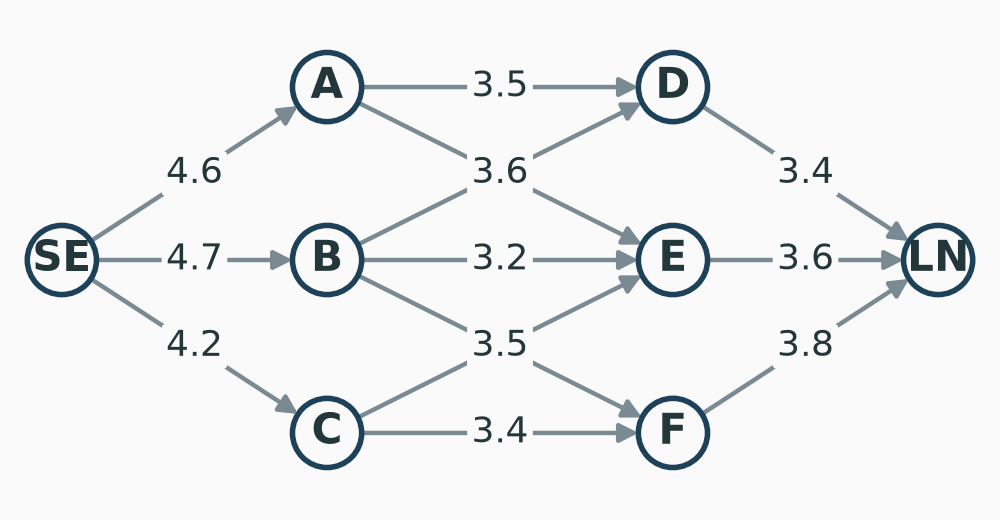

Lecture 06’s flight, Seattle (SE) to London (LN); hours on each arc.

**(a)** Name the stages, states and controls.  
**(b)** Build the backward tables; find the fastest route.  
**(c)** Compare the work with lecture 06’s table.

## Part II: Continuous States and Probabilistic Recursions

When the state is a number on a line, and when chance picks the next state

# Discrete and Continuous States: The Endpoint Argument

## Three New Products, One Plant

| Product | 1 | 2 | 3 |
| --- | --- | --- | --- |
| Start-up cost ${c}$ | 3 | 2 | 0 |
| Marginal net revenue ${r}$ | 2 | 3 | 1 |
| Capacity per unit (plant: 100%) | 20% | 40% | 20% |
| Maximum demand | 3 | no limit | no limit |

- Starting a product costs ${c}$ once; each unit then adds ${r}$
- **Decide** how many units of each to make, to maximize net revenue minus start-up costs

**(a)** Integer units. **(b)** Divisible units. A past Exam 2 problem, 60 of 100 points.

## Integer Production: The State in 20% Blocks

- Stage ${k}$: product ${k + 1}$; control ${u_k}$: units made
- State ${x_k}$: capacity left in **blocks of 20%**; 100% is 5 blocks, so ${x_0 = 5}$
- One unit of product ${k + 1}$ uses ${a_k}$ blocks: ${a_0 = 1}$ (20%), ${a_1 = 2}$ (40%), ${a_2 = 1}$ (20%)
- Profit of ${u_k}$ units: ${g_k(u_k) = r\,u_k - c}$ if ${u_k > 0}$, and 0 if ${u_k = 0}$, with product ${k + 1}$’s ${r}$ and ${c}$

$$\begin{alignat*}{2}
J^*_k(x_k) & {}= \max_{u_k} \big[\, g_k(u_k) + J^*_{k+1}(x_k - a_k\, u_k) \big] \\[4pt]
J^*_2(x_2) & {}= x_2
\end{alignat*}$$

- Product 3 has no start-up cost, so it takes every block left

## Integer Production: Backward Tables

| *k* = 2 *x*<sub>2</sub> | *J*<sub>2</sub>*(*x*<sub>2</sub>) | *u*<sub>2</sub>* |
| --- | --- | --- |
| 0 | 0 | 0 |
| 1 | 1 | 1 |
| 2 | 2 | 2 |
| 3 | 3 | 3 |
| 4 | 4 | 4 |
| 5 | 5 | 5 |

| *k* = 1 *x*<sub>1</sub> | *g*<sub>1</sub>(*u*<sub>1</sub>) + *J*<sub>2</sub>*(*x*<sub>1</sub> − 2*u*<sub>1</sub>) 0 | *g*<sub>1</sub>(*u*<sub>1</sub>) + *J*<sub>2</sub>*(*x*<sub>1</sub> − 2*u*<sub>1</sub>) 1 | *g*<sub>1</sub>(*u*<sub>1</sub>) + *J*<sub>2</sub>*(*x*<sub>1</sub> − 2*u*<sub>1</sub>) 2 | *J*<sub>1</sub>*(*x*<sub>1</sub>) | *u*<sub>1</sub>* |  |  |
| --- | --- | --- | --- | --- | --- | --- | --- |
| 0 | 0 + 0 = 0 |  |  |  |  | 0 | 0 |
| 1 | 0 + 1 = 1 |  |  | 1 | 0 |  |  |
| 2 | 0 + 2 = 2 | 1 + 0 = 1 |  | 2 | 0 |  |  |
| 3 | 0 + 3 = 3 | 1 + 1 = 2 |  | 3 | 0 |  |  |
| 4 | 0 + 4 = 4 | 1 + 2 = 3 | 4 + 0 = 4 | 4 | 0 or 2 |  |  |
| 5 | 0 + 5 = 5 | 1 + 3 = 4 | 4 + 1 = 5 | 5 | 0 or 2 |  |  |

| *k* = 0 *x*<sub>0</sub> | *g*<sub>0</sub>(*u*<sub>0</sub>) + *J*<sub>1</sub>*(5 − *u*<sub>0</sub>) 0 | *g*<sub>0</sub>(*u*<sub>0</sub>) + *J*<sub>1</sub>*(5 − *u*<sub>0</sub>) 1 | *g*<sub>0</sub>(*u*<sub>0</sub>) + *J*<sub>1</sub>*(5 − *u*<sub>0</sub>) 2 | *g*<sub>0</sub>(*u*<sub>0</sub>) + *J*<sub>1</sub>*(5 − *u*<sub>0</sub>) 3 | *J*<sub>0</sub>*(*x*<sub>0</sub>) | *u*<sub>0</sub>* |  |  |
| --- | --- | --- | --- | --- | --- | --- | --- | --- |
| 5 | 0 + 5 = 5 | −1 + 4 = 3 | 1 + 3 = 4 | 3 + 2 = 5 |  |  | 5 | 0 or 3 |

## Three Optimal Plans

- ${u^*_0 = 0}$: ${x_1 = 5}$, ${u^*_1 = 0}$ or 2
  - ${u_1 = 0}$: ${x_2 = 5}$, ${u_2 = 5}$
  - ${u_1 = 2}$: ${x_2 = 1}$, ${u_2 = 1}$
- ${u^*_0 = 3}$: ${x_1 = 2}$, ${u^*_1 = 0}$; ${x_2 = 2}$, ${u_2 = 2}$

Three optimal plans, profit 5

| ${(u_0, u_1, u_2)}$ | Profit |
| --- | --- |
| (0, 0, 5) | ${5}$ |
| (0, 2, 1) | ${(6 - 2) + 1 = 5}$ |
| (3, 0, 2) | ${(6 - 3) + 2 = 5}$ |

**Read every tie forward**

A tie in ${u^*_k}$ branches the forward pass. The exam asks for **all** optimal plans.

## Divisible Units: Percent of Capacity as the State

| Stage ${k}$ | 0 | 1 | 2 |
| --- | --- | --- | --- |
| Product | 1 | 2 | 3 |
| Revenue per unit ${r_k}$ | 2 | 3 | 1 |
| Start-up cost ${c_k}$ | 3 | 2 | 0 |
| Percent per unit ${a_k}$ | 20 | 40 | 20 |

- State ${x_k}$: **percent** of capacity left, any number from 0 to 100; ${x_0 = 100}$
- ${g_k(u_k) = r_k u_k - c_k}$ if ${u_k > 0}$, and 0 if ${u_k = 0}$; ${u_0 \le 3}$ (demand)

$$Q^*_k(x_k, u_k) = g_k(u_k) + J^*_{k+1}(x_k - a_k u_k), \qquad 0 \le u_k \le x_k/a_k$$

- **Stage 2** (${c_2 = 0}$): ${u^*_2 = x_2/a_2}$ and ${J^*_2(x_2) = r_2\,x_2/a_2 = x_2/20}$

## Divisible Units: Only the Endpoints Matter

- **Stage 1** (product 2), if ${u_1 > 0}$:

$$\begin{alignat*}{2}
Q^*_1(x_1, u_1) & {}= r_1 u_1 - c_1 + J^*_2(x_1 - a_1 u_1) \\[4pt]
& {}= 3u_1 - 2 + \frac{x_1 - 40u_1}{20} \\[4pt]
& {}= \frac{x_1}{20} - 2 + u_1
\end{alignat*}$$

- Slope ${r_1 - r_2\,a_1/a_2 = 3 - 1(40/20) = 1}$: the best ${u_1}$ is an **endpoint**, 0 or ${x_1/a_1 = x_1/40}$

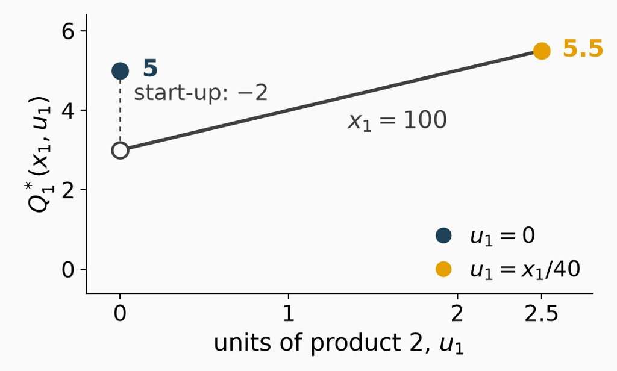

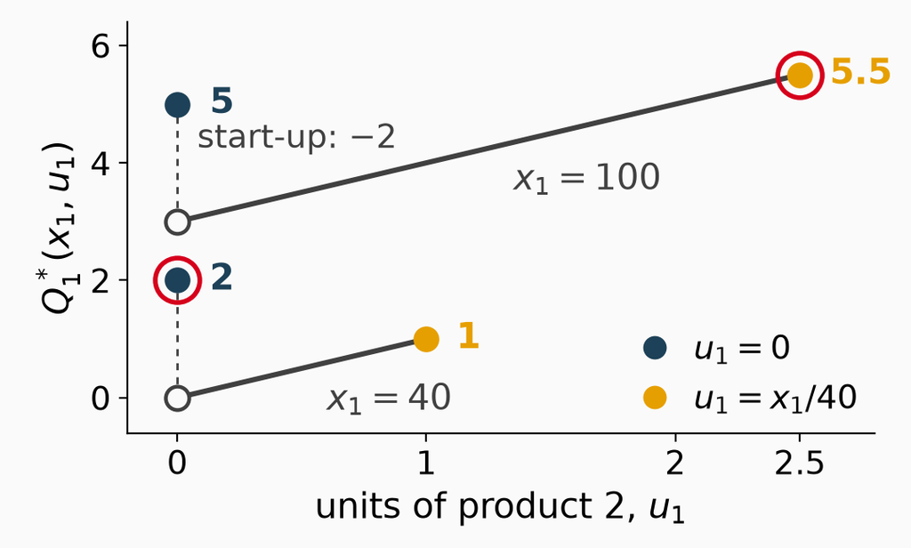

## Divisible Units: The Switch at 80%

- If ${u_1 = 0}$, all to product 3: ${J^*_2(x_1) = x_1/20}$
- If ${u_1 = x_1/a_1}$, all to product 2: ${r_1 x_1/a_1 - c_1 = 3x_1/40 - 2}$
- Product 2 wins when ${3x_1/40 - 2 \ge x_1/20}$, that is ${x_1 \ge 80}$

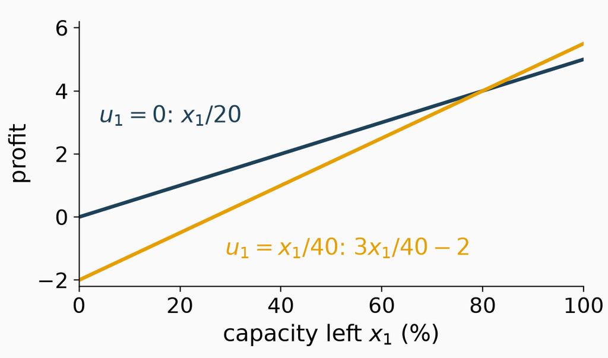

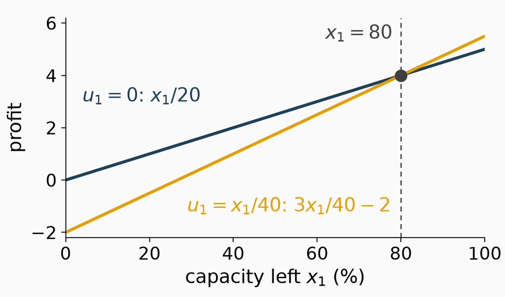

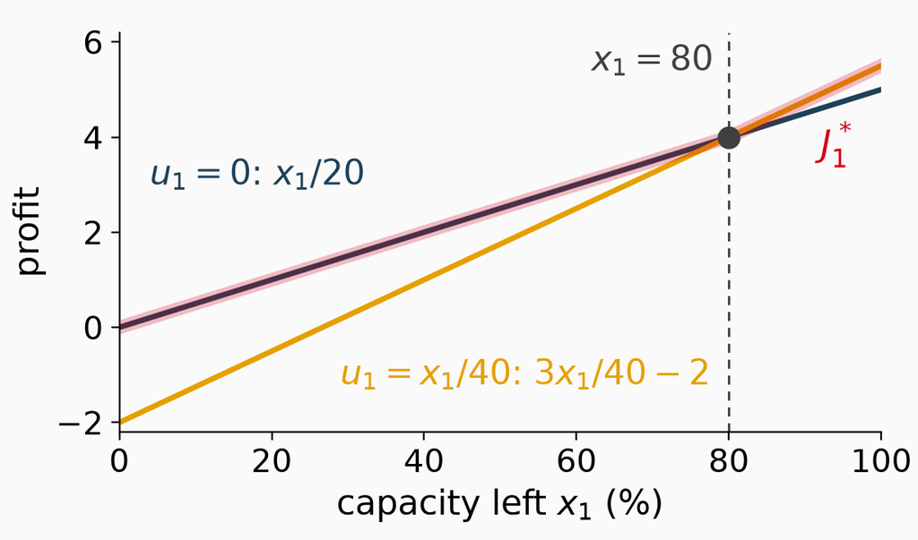

**Stage 1 in one formula: the switch is at 80%**

$$J^*_1(x_1) = \max\Big\{ \frac{x_1}{20},\; \frac{3x_1}{40} - 2 \Big\}:
\qquad u^*_1 = 0 \text{ if } x_1 \le 80,
\qquad u^*_1 = \frac{x_1}{40} \text{ if } x_1 \ge 80$$

## Divisible Units: Stage 0 and the Value of Capacity

$$\begin{alignat*}{3}
Q^*_0(100, u_0) & {}= r_0 u_0 - c_0 + J^*_1(x_0 - a_0 u_0) && \qquad 0 < u_0 \le 3 \\[4pt]
& {}= 2u_0 - 3 + J^*_1(100 - 20u_0) \\[4pt]
Q^*_0(100, 0) & {}= J^*_1(100)
\end{alignat*}$$

- At stage 1, one percent of capacity is worth at most ${r_1/a_1 = 3/40}$, the slope of ${J^*_1}$ above 80 (below 80 it is ${r_2/a_2 = 1/20}$)
- One more unit of product 1 earns ${r_0 = 2}$ and uses ${a_0 = 20}$%, worth at most ${a_0\,r_1/a_1 = 20(3)/40 = 1.5}$ at stage 1
- ${2 > 1.5}$, so ${Q^*_0}$ rises on ${0 < u_0 \le 3}$: the best positive level is the demand limit, ${u_0 = 3}$

## Divisible Units: Stage 0, Two Candidates

- If ${u_0 = 0}$: ${x_1 = x_0 = 100 \ge 80}$, so ${J^*_1(100) = r_1 x_1/a_1 - c_1}$ ${= 3(100)/40 - 2 =}$ **5.5**
- If ${u_0 = 3}$: ${x_1 = x_0 - a_0 u_0}$ ${= 100 - 20(3) = 40 < 80}$, so ${J^*_1(40) = r_2 x_1/a_2 = 1(40)/20 = 2}$ and ${Q^*_0 = r_0 u_0 - c_0 + 2}$ ${= 2(3) - 3 + 2 =}$ **5**
- ${5.5 > 5}$: ${u^*_0 = 0}$, no product 1

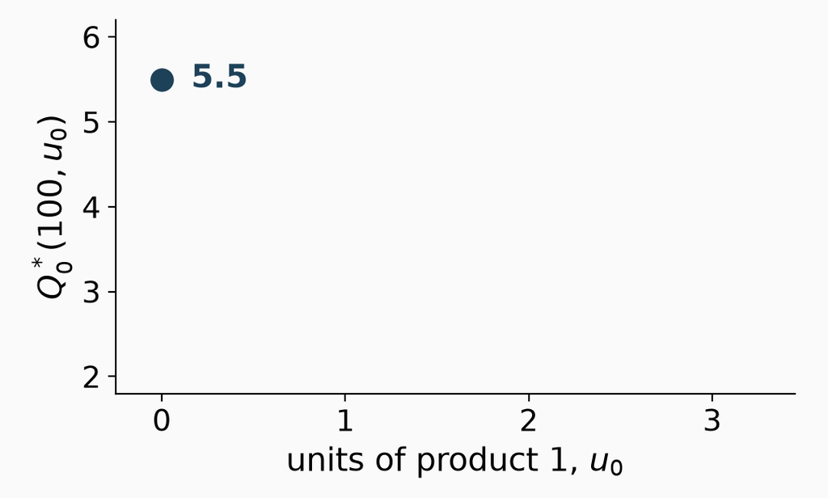

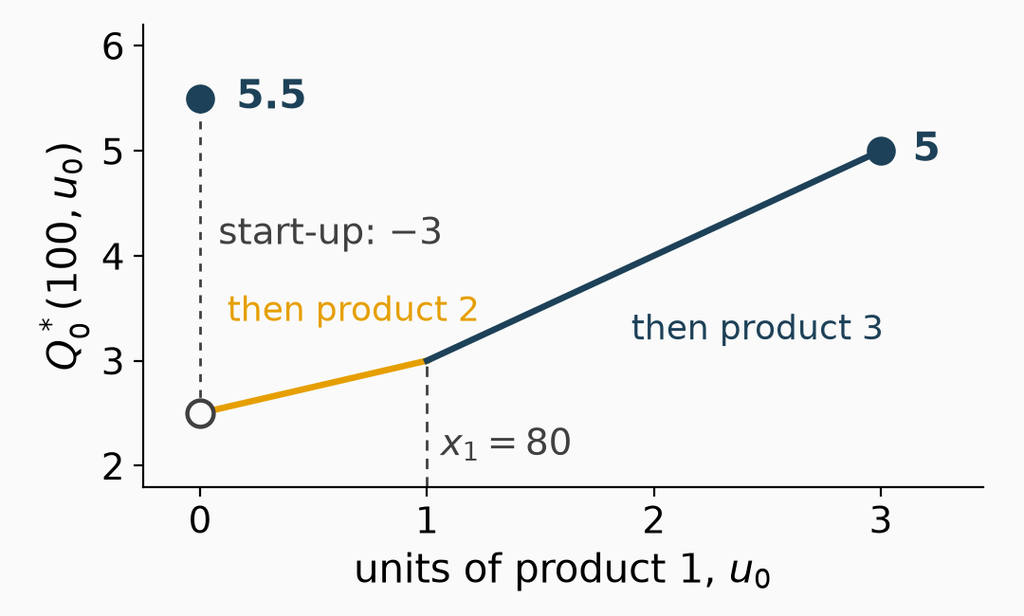

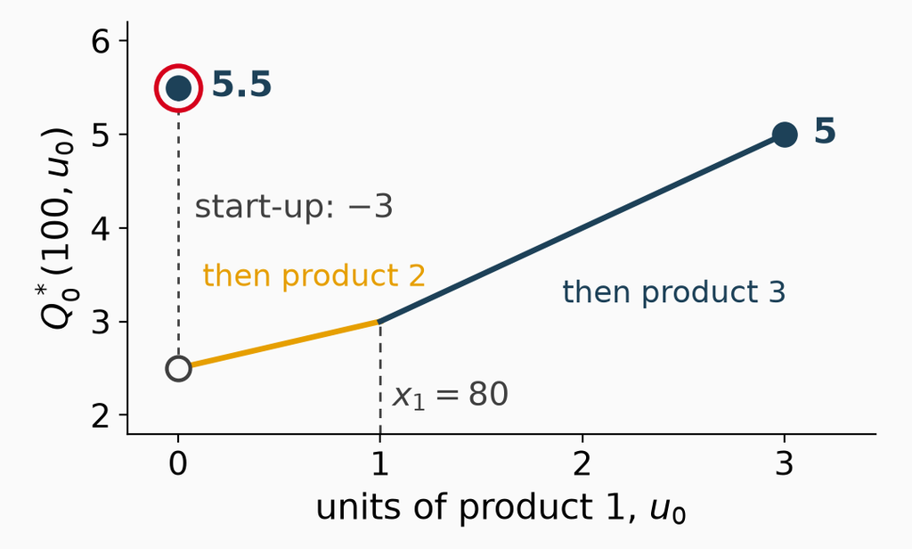

## Divisible Units: The Plan Read Forward

- ${u_0 = 0}$, so ${x_1 = x_0 - a_0 u_0 = 100}$
- ${x_1 = 100 \ge 80}$, so ${u_1 = x_1/a_1 = 100/40 = 2.5}$
- ${x_2 = x_1 - a_1 u_1 = 100 - 40(2.5) = 0}$, so ${u_2 = x_2/a_2 = 0}$

**Divisible optimum 5.5: 2.5 units of product 2 only**

${g_1(2.5) = r_1 u_1 - c_1 = 3(2.5) - 2 = 5.5}$. The integer optimum was 5: divisibility adds 0.5.

# Continuous States by Calculus: Employment Levels

## The Local Job Shop

- Workers needed each season: the chart, from this spring to the next
- No overtime and no inventory: custom orders
- A worker above the requirement costs **$2,000** a season
- Changing the level costs **$200 × (change)²**
- Part-time workers make fractional levels possible

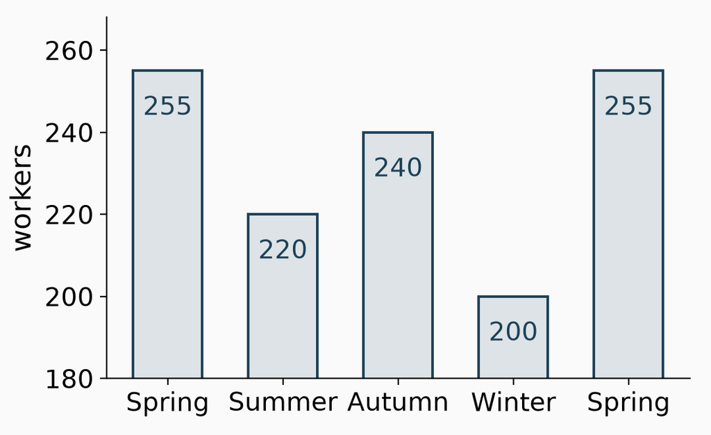

## Two Extreme Plans

- **Hold 255** all year: 35, 15 and 55 idle workers

  2,000 × (35 + 15 + 55) = **$210,000**
- **Follow the requirement**: changes of 35, 20, 40 and 55

  200 × (35² + 20² + 40² + 55²) = **$1,250,000**

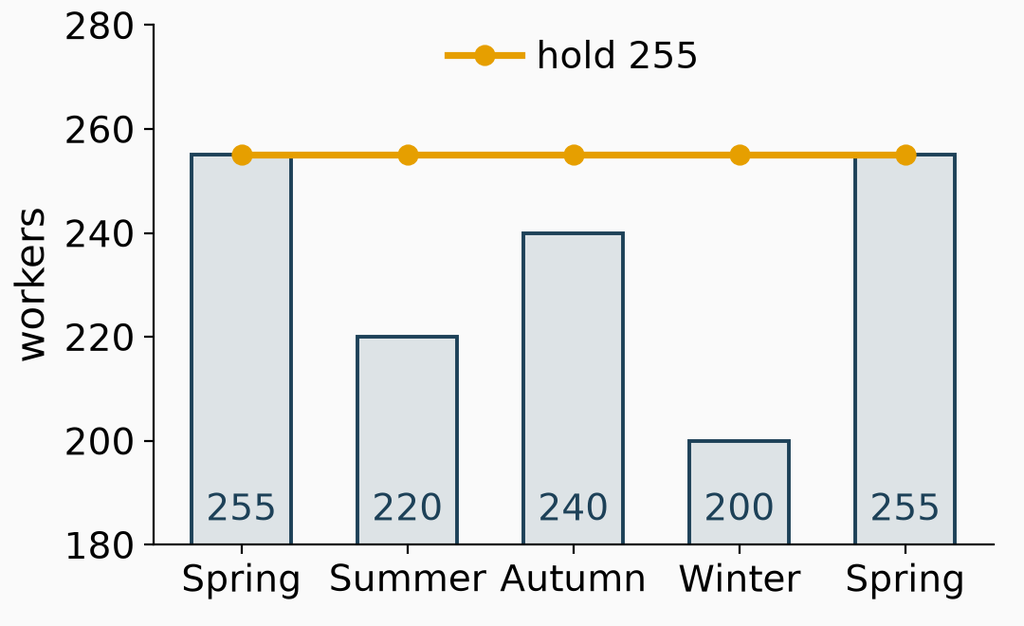

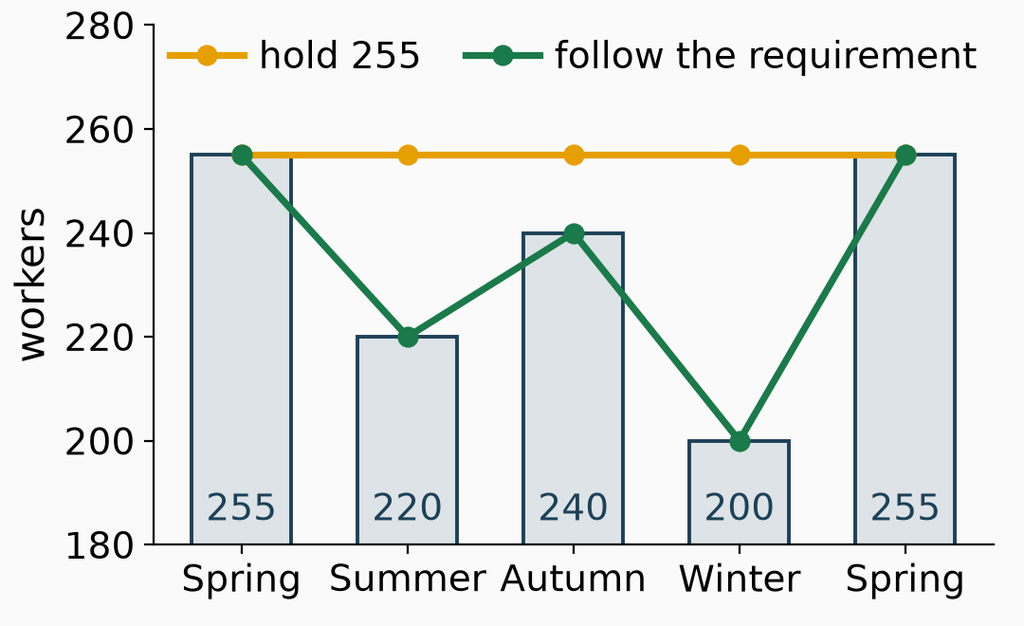

- The optimum costs less than $210,000: how far below 255?

## Seasons as Stages, Last Season’s Level as the State

| Stage ${k}$ | 0 | 1 | 2 | 3 |
| --- | --- | --- | --- | --- |
| Season | Summer | Autumn | Winter | Spring |
| Requirement ${r_k}$ | 220 | 240 | 200 | 255 |

- Control ${u_k}$: workers in season ${k}$, with ${u_k \ge r_k}$
- State ${x_k}$: **last season’s level**, all that the change cost needs from the past; ${x_0 = 255}$, this spring’s level
- System: this season’s level is next season’s state, ${x_{k+1} = u_k}$

## One Season’s Cost: Change Plus Idle Workers

$$g_k(x_k, u_k) = \underbrace{c\,(u_k - x_k)^2}_{\text{change}}
+ \underbrace{h\,(u_k - r_k)}_{\text{idle workers}},
\qquad c = 200, \quad h = 2000$$

- The chart’s autumn: summer held ${x_1 = 250}$, autumn holds ${u_1 = 245}$

$$\begin{alignat*}{2}
g_1 & {}= c\,(u_1 - x_1)^2 + h\,(u_1 - r_1) \\[4pt]
& {}= 200\,(245 - 250)^2 + 2000\,(245 - 240) \\[4pt]
& {}= 5{,}000 + 10{,}000 = 15{,}000
\end{alignat*}$$

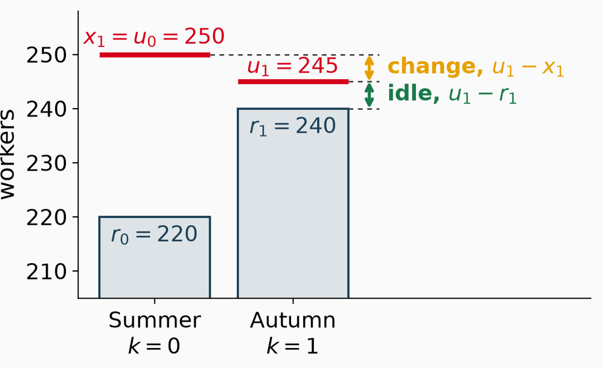

## The Recursion: This Season’s Cost Plus the Cost-to-Go

$$\begin{alignat*}{2}
Q^*_k(x_k, u_k) & {}= c\,(u_k - x_k)^2 + h\,(u_k - r_k) + J^*_{k+1}(u_k) \\[4pt]
J^*_k(x_k) & {}= \min_{r_k \le u_k \le r_3} Q^*_k(x_k, u_k)
\end{alignat*}$$

- **Stage 3** (spring): ${u_3 = r_3}$, no choice and no idle worker

$$J^*_3(x_3) = c\,(r_3 - x_3)^2 = 200\,(255 - x_3)^2$$

**A continuous state**

${x_k}$ can be any number in an interval: no table can list it. Each ${J^*_k}$ is a **formula** in ${x_k}$, found by setting the derivative of ${Q^*_k}$ in ${u_k}$ to 0.